# Assigment: Trend Surfaces

2021-02-21

# 1 Dataset

Task: Load the “Northeast Climate” R Dataset `ne_stations.RData`, with the `load` function. Use the `verbose=TRUE` optional argument to display the names of the objects that are loaded.

```r
require(sp)
require(gstat)
require(lattice)
load("ne_stations.RData",verbose = TRUE)
```

```
## Loading objects:
##   ne
##   ne.m
##   ne.df
##   state.ne
##   state.ne.m
##   ne.crs
```

Q: What are the data types of these objects? For those that are spatial, what are their coördinate reference systems (CRS)?

Note: you will have to load the `sp` package to see the CRS.

A:dataframes, latitude, longitude, two coordinates (East and North)

We will work mostly with object `ne.df`, a dataframe version of the climate stations.

Q: For how many climate stations are there records? How many states of the USA are represented?

A: 305, 4

Task: Display the names of the variables in this dataset.

```r
colnames(ne.df)
```

```
##  [1] "STATION_ID" "STATE"      "STATION_NA" "LATITUDE_D" "LONGITUDE_"
##  [6] "ELEVATION_" "OID_"       "COOP_ID"    "STATE_1"    "STN_NAME"
## [11] "LAT_DD"     "LONG_DD"    "ELEV_FT"    "JAN_GDD50"  "FEB_GDD50"
## [16] "MAR_GDD50"  "APR_GDD50"  "MAY_GDD50"  "JUN_GDD50"  "JUL_GDD50"
## [21] "AUG_GDD50"  "SEP_GDD50"  "OCT_GDD50"  "NOV_GDD50"  "DEC_GDD50"
## [26] "ANN_GDD50"  "E"          "N"
```

Q: What are the attributes in the `ne.df` data frame?

A: [1] “STATION_ID” “STATE” “STATION_NA” “LATITUDE_D” [5] “LONGITUDE_” “ELEVATION_” “OID_” “COOP_ID”  
[9] “STATE_1” “STN_NAME” “LAT_DD” “LONG_DD”  
[13] “ELEV_FT” “JAN_GDD50” “FEB_GDD50” “MAR_GDD50” [17] “APR_GDD50” “MAY_GDD50” “JUN_GDD50” “JUL_GDD50” [21] “AUG_GDD50” “SEP_GDD50” “OCT_GDD50” “NOV_GDD50” [25] “DEC_GDD50” “ANN_GDD50” “E” “N”

The response variable here is `ANN_GDD50` (annual growing-degree days), the coördinates are in fields `E` and `N`, the elevation of the station is in field `ELEVATION_`.

# 2 First-order trend surface

Task: Compute a first-order trend surface model using the two coordinates (East and North) as the predictors, and the growing degree days as the dependent (response) variable, using Ordinary Least Squares linear regression.

Display its summary and the linear model diagnostic plots “residuals vs. fitted” and “Normal Q-Q”.

```r
ne.sp<-ne.df
coordinates(ne.sp)<-c("E","N")
#how do we know the units was m? why do we use median not mean?
#ne.df$E<-(ne.df$E-median(ne.df$E))/1000
#ne.df$N<-(ne.df$N-median(ne.df$N))/1000

model.ts1<-lm(ne.df$ANN_GDD50~ne.df$E+ne.df$N)
summary(model.ts1)
```

```
##
## Call:
## lm(formula = ne.df$ANN_GDD50 ~ ne.df$E + ne.df$N)
##
## Residuals:
##      Min       1Q   Median       3Q      Max
## -1207.36  -232.79    27.11   259.59   847.42
##
## Coefficients:
##               Estimate Std. Error t value Pr(>|t|)
## (Intercept)  2.298e+03  2.381e+01  96.478  < 2e-16 ***
## ne.df$E      7.483e-04  1.211e-04   6.181 2.07e-09 ***
## ne.df$N     -2.818e-03  1.369e-04 -20.577  < 2e-16 ***
## ---
## Signif. codes:  0 '***' 0.001 '**' 0.01 '*' 0.05 '.' 0.1 ' ' 1
##
## Residual standard error: 371.5 on 302 degrees of freedom
## Multiple R-squared:  0.5837, Adjusted R-squared:  0.581
## F-statistic: 211.7 on 2 and 302 DF,  p-value: < 2.2e-16
```

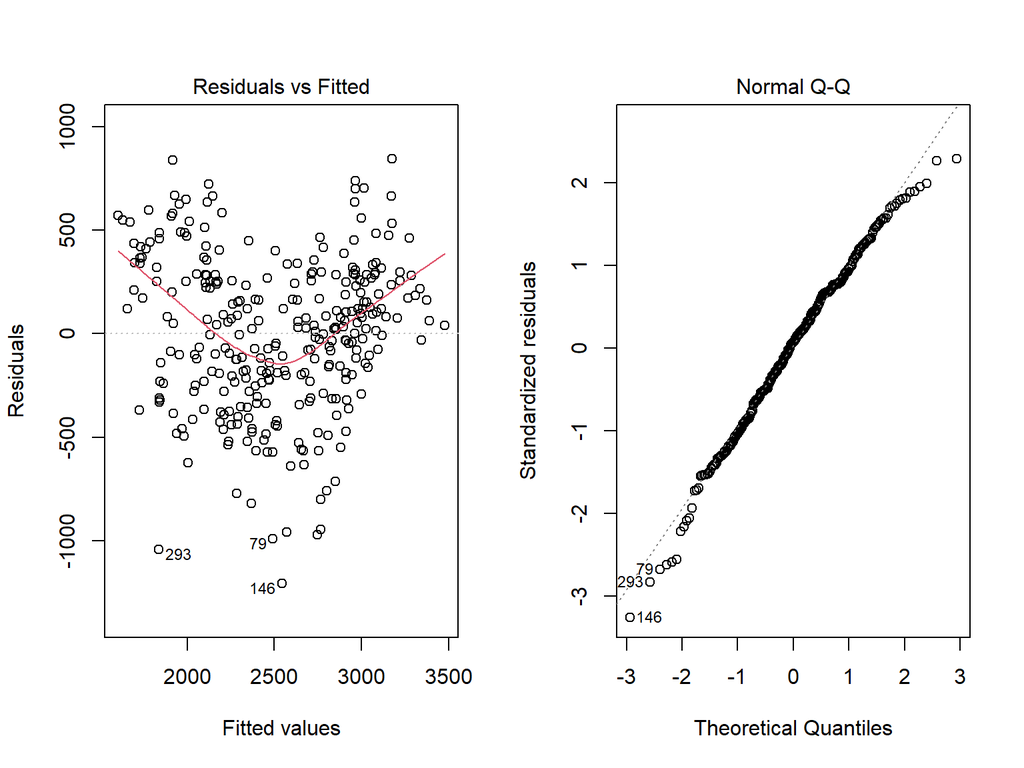

```r
par(mfrow=c(1,2))
plot(model.ts1,which=1:2)
```

Q: What proportion of the variation in GDD50 is explained by the first-order trend?

A: 0.5837

Q: Which of the two coördinates most affects the GDD50?

A: N

Q: Is there a relation between the fitted values and residuals? If so, what?

A: Yes. non-linear relationship.

Q: Are the residuals normally-distributed? If not, how so? Are there any especially large residuals?

A: No. Yes.

Optional Task: Identify the most poorly-modelled station.

```r
range(model.ts1$residuals)
```

```
## [1] -1207.3594   847.4215
```

```r
outid<-which(model.ts1$residuals<(-1000))
ne.df[outid,3]
```

```
## [1] "SLIDE MOUNTAIN"  "MOUNT MANSFIELD"
```

Optional Q: Where is this? Why might it be so poorly modelled?

Optional A: May be they are on mountains.

Task: Display a post-plot of the residuals, with the positive residuals (under-predictions) shown in green and the negative (over-predictions) in red.

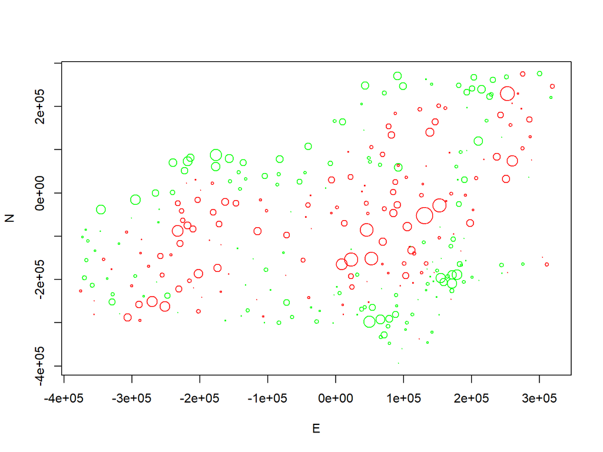

```r
res.ts1<-residuals(model.ts1)
plot(ne.df$N~ne.df$E,cex = 3*abs(res.ts1)/max(abs(res.ts1)),
     col=ifelse(res.ts1>0,"green","red"),
     xlab="E",ylab="N")
```

Q: What is the spatial pattern of the trend-surface residuals? Does it suggest a higher-order trend?

# 3 Second-order trend surface

Task: Repeat all the steps of the previous section, and answer the same questions, for a full 2nd-order trend surface.

```r
model.ts2<-lm(ne.df$ANN_GDD50~ne.df$E+ne.df$N+I((ne.df$E)^2)+I((ne.df$N)^2)+I((ne.df$E)*(ne.df$N)))
summary(model.ts2)
```

```
##
## Call:
## lm(formula = ne.df$ANN_GDD50 ~ ne.df$E + ne.df$N + I((ne.df$E)^2) +
##     I((ne.df$N)^2) + I((ne.df$E) * (ne.df$N)))
##
## Residuals:
##      Min       1Q   Median       3Q      Max
## -1076.18  -214.61    37.77   229.11   792.40
##
## Coefficients:
##                            Estimate Std. Error t value Pr(>|t|)
## (Intercept)               2.131e+03  3.529e+01  60.402  < 2e-16 ***
## ne.df$E                  -8.336e-05  1.444e-04  -0.577    0.564
## ne.df$N                  -1.523e-03  1.788e-04  -8.520 7.95e-16 ***
## I((ne.df$E)^2)            2.821e-09  6.927e-10   4.073 5.95e-05 ***
## I((ne.df$N)^2)            7.526e-09  8.380e-10   8.981  < 2e-16 ***
## I((ne.df$E) * (ne.df$N)) -8.036e-09  9.691e-10  -8.292 3.84e-15 ***
## ---
## Signif. codes:  0 '***' 0.001 '**' 0.01 '*' 0.05 '.' 0.1 ' ' 1
##
## Residual standard error: 323.9 on 299 degrees of freedom
## Multiple R-squared:  0.6868, Adjusted R-squared:  0.6816
## F-statistic: 131.1 on 5 and 299 DF,  p-value: < 2.2e-16
```

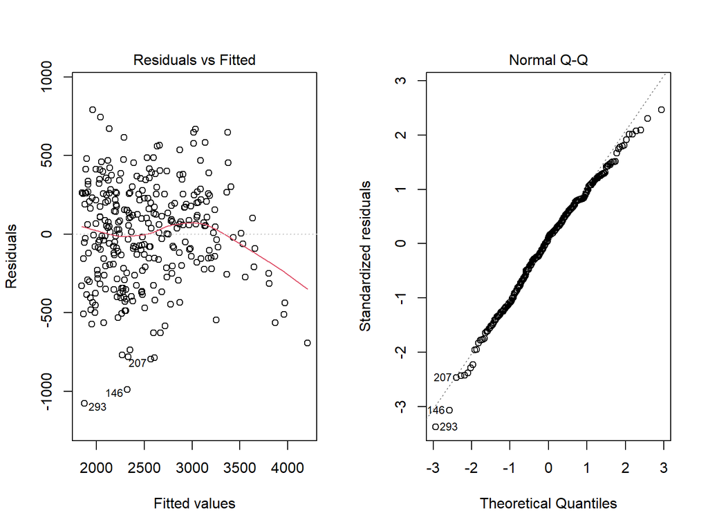

```r
par(mfrow=c(1,2))
plot(model.ts2,which=1:2)
```

Q: What proportion of the variation in GDD50 is explained by the second-order trend?

A: 0.6868

Q: Which of the two coördinates (taking into account their squares also) most affects the GDD50?

A: `I((ne.df$N)^2)`, `I((ne.df$E) * (ne.df$N))`

Q: Is there a relation between the fitted values and residuals? If so, what?

A: Maybe not.

Q: Are the residuals normally-distributed? If not, how so? Are there any especially large residuals?

A: Mostly are normally distributed. Yes.

Optional Task: Identify the most poorly-modelled station.

```r
outid<-which(model.ts2$residuals<(-1000))
ne.df[outid,3]
```

```
## [1] "MOUNT MANSFIELD"
```

Optional Q: Where is this? Why might it be so poorly modelled?

Optional A: “MOUNT MANSFIELD”. Mountains?

Task: Display a post-plot of the residuals, with the positive residuals (under-predictions) shown in green and the negative (over-predictions) in red.

[figure not shown]

```r
res.ts2<-residuals(model.ts2)
plot(ne.df$N~ne.df$E,cex = 3*abs(res.ts1)/max(abs(res.ts2)),
     col=ifelse(res.ts2>0,"green","red"),
     xlab="E",ylab="N")
```

Q: What is the spatial pattern of the trend-surface residuals? Does it suggest a higher-order trend?

A: large residuals are still clustered. May be a higher-order trend.

# 4 Comparing trend orders

Task: Compare the two orders of trend surfaces with an analysis of variance.

```r
anova(model.ts1,model.ts2)
```

```
## Analysis of Variance Table
##
## Model 1: ne.df$ANN_GDD50 ~ ne.df$E + ne.df$N
## Model 2: ne.df$ANN_GDD50 ~ ne.df$E + ne.df$N + I((ne.df$E)^2) + I((ne.df$N)^2) +
##     I((ne.df$E) * (ne.df$N))
##   Res.Df      RSS Df Sum of Sq     F    Pr(>F)
## 1    302 41685611
## 2    299 31361422  3  10324189 32.81 < 2.2e-16 ***
## ---
## Signif. codes:  0 '***' 0.001 '**' 0.01 '*' 0.05 '.' 0.1 ' ' 1
```

Q: Is the 2nd-order trend clearly superior to the 1st-order trend?

A: Yes.

# 5 Mapping

Task: Load the `raster` package into the workspace.

Then, load a gridded DEM covering the study area `dem_nj_ny_pa_vt_4km.RData`, with the `load` function. Use the `verbose=TRUE` optional argument to display the names of the objects that are loaded.

```r
load("dem_nj_ny_pa_vt_4km.RData",verbose=TRUE)
```

```
## Loading objects:
##   dem.ne.m.sp
```

```r
str(dem.ne.m.sp)
```

```
## Formal class 'SpatialPixelsDataFrame' [package "sp"] with 7 slots
##   ..@ data       :'data.frame':  22649 obs. of  1 variable:
##   .. ..$ ELEVATION_: num [1:22649] 1268 1312 953 610 671 ...
##   ..@ coords.nrs : num(0)
##   ..@ grid       :Formal class 'GridTopology' [package "sp"] with 3 slots
##   .. .. ..@ cellcentre.offset: Named num [1:2] -384274 -393450
##   .. .. .. ..- attr(*, "names")= chr [1:2] "E" "N"
##   .. .. ..@ cellsize         : Named num [1:2] 3450 3704
##   .. .. .. ..- attr(*, "names")= chr [1:2] "E" "N"
##   .. .. ..@ cells.dim        : Named int [1:2] 216 185
##   .. .. .. ..- attr(*, "names")= chr [1:2] "E" "N"
##   ..@ grid.index : int [1:22649] 214 215 403 404 405 406 409 410 411 412 ...
##   ..@ coords     : num [1:22649, 1:2] 350576 354026 257426 260876 264326 ...
##   .. ..- attr(*, "dimnames")=List of 2
##   .. .. ..$ : NULL
##   .. .. ..$ : chr [1:2] "E" "N"
##   ..@ bbox       : num [1:2, 1:2] -385999 -395302 355751 289938
##   .. ..- attr(*, "dimnames")=List of 2
##   .. .. ..$ : chr [1:2] "E" "N"
##   .. .. ..$ : chr [1:2] "min" "max"
##   ..@ proj4string:Formal class 'CRS' [package "sp"] with 1 slot
##   .. .. ..@ projargs: chr "+proj=aea +lat_0=42.5 +lat_1=39 +lat_2=44 +lon_0=-76 +ellps=WGS84 +units=m"
```

Q: What object is loaded? What is its class? What is its CRS? Which of the point datasets does this match?

A: dem.ne.m.sp, large spatial pixels dataframe, N,E coordinates, I dont know which of the point datasets does this match.

Q: What is the bounding box and resolution of the grid? (You can see these with the `summary` function.)

```r
bbox(dem.ne.m.sp)
```

```
##         min      max
## E -385999.3 355750.7
## N -395302.4 289937.6
```

```r
summary(dem.ne.m.sp)
```

```
## Object of class SpatialPixelsDataFrame
## Coordinates:
##         min      max
## E -385999.3 355750.7
## N -395302.4 289937.6
## Is projected: TRUE
## proj4string :
## [+proj=aea +lat_0=42.5 +lat_1=39 +lat_2=44 +lon_0=-76 +ellps=WGS84
## +units=m]
## Number of points: 22649
## Grid attributes:
##   cellcentre.offset cellsize cells.dim
## E         -384274.3     3450       216
## N         -393450.4     3704       185
## Data attributes:
##    ELEVATION_
##  Min.   :  -6.697
##  1st Qu.: 602.504
##  Median :1173.889
##  Mean   :1125.085
##  3rd Qu.:1587.356
##  Max.   :3992.470
```

A: min max E -385999.3 355750.7 N -395302.4 289937.6 cellcentre.offset cellsize E -384274.3 3450  
N -393450.4 3704

Task: Display the grid with the `spplot` function.

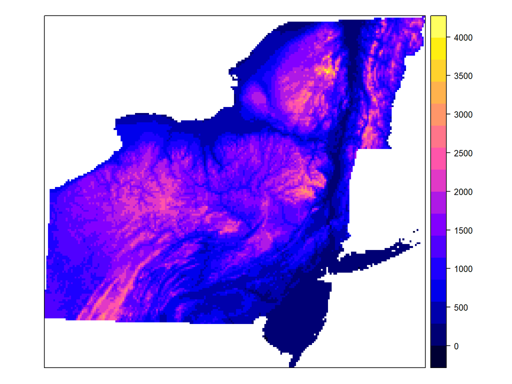

```r
spplot(dem.ne.m.sp)
```

Task: Predict over this study area with the 2nd-order trend surface. Add this as a field in the study area data frame.

```r
pred.ts2<-predict.lm(model.ts2, newdata=dem.ne.m.sp@grid,interval = "prediction",level = .95)
summary(pred.ts2)
```

```
##       fit            lwr            upr
##  Min.   :1842   Min.   :1187   Min.   :2496
##  1st Qu.:2136   1st Qu.:1494   1st Qu.:2779
##  Median :2424   Median :1783   Median :3066
##  Mean   :2518   Mean   :1874   Mean   :3161
##  3rd Qu.:2841   3rd Qu.:2201   3rd Qu.:3481
##  Max.   :4209   Max.   :3547   Max.   :4871
```

```r
summary(ne.df$ANN_GDD50)
```

```
##    Min. 1st Qu.  Median    Mean 3rd Qu.    Max.
##     795    2100    2463    2518    2930    4021
```

Task: Summarize the predictions.

Q: How do the predictions compare with the summary of the weather stations observations?

A: Not very good

Task: Display a map of the predictions using the `spplot` function, and specifying the field to display with the `zcol` argument to `spplot`.

```r
#'newdata' had 22649 rows but variables found have 305 rows
#pred.ts2<-predict.lm(model.ts2, newdata=as.data.frame(dem.ne.m.sp@coords),interval = "prediction",level = .95)

#sp.grid<-SpatialPointsDataFrame(coords = coordinates(dem.ne.m.sp@grid),data = as.data.frame(pred.ts2))
```

Q: Is this trend surface a realistic representation of the growing-degree days? Explain.

A:

# 6 Generalized Additive Model (GAM)

Task: Display a scatterplot of the GDD50 against the two coördinates.

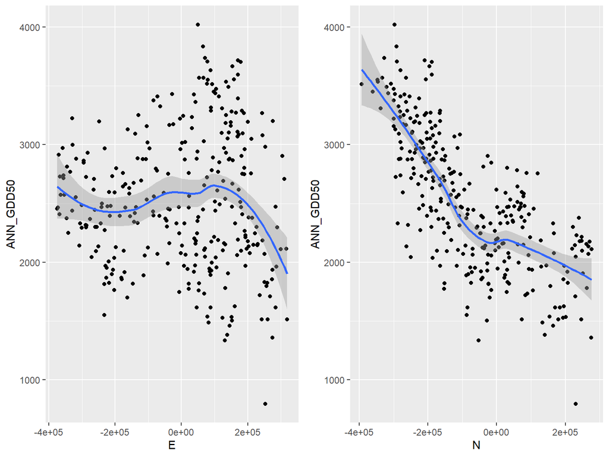

```r
require(ggplot2)
g1<-ggplot(ne.df,aes(x=E,y=ANN_GDD50))+
  geom_point()+
  geom_smooth(method="loess")

g2<-ggplot(ne.df,aes(x=N,y=ANN_GDD50))+
  geom_point()+
  geom_smooth(method="loess")

require(gridExtra)
grid.arrange(g1,g2,ncol=2)
```

Q: Do these relations look linear or quadratic throughout their ranges?

A: quadratic

Task: Compute a Generalized Additive Model (GAM) of GDD50 modelled by the two coördinates.

```r
require(mgcv)
ne.df$E<-coordinates(ne.sp)[,1]
ne.df$N<-coordinates(ne.sp)[,2]
model.gam<-gam(ANN_GDD50~s(E,N),data = ne.df)
summary(model.gam)
```

```
##
## Family: gaussian
## Link function: identity
##
## Formula:
## ANN_GDD50 ~ s(E, N)
##
## Parametric coefficients:
##             Estimate Std. Error t value Pr(>|t|)
## (Intercept)  2517.52      15.73     160   <2e-16 ***
## ---
## Signif. codes:  0 '***' 0.001 '**' 0.01 '*' 0.05 '.' 0.1 ' ' 1
##
## Approximate significance of smooth terms:
##          edf Ref.df     F p-value
## s(E,N) 24.46   27.8 36.98  <2e-16 ***
## ---
## Signif. codes:  0 '***' 0.001 '**' 0.01 '*' 0.05 '.' 0.1 ' ' 1
##
## R-sq.(adj) =  0.771   Deviance explained = 78.9%
## GCV =  82348  Scale est. = 75474     n = 305
```

Q: What proportion of the variation in GDD50 is explained by the GAM? How does this compare to the 2nd-order trend surface?

A: 78.9%, more

Task: Predict over this study area with the fitted GAM. Add this as a field in the study area data frame.

Note: you will have to convert the `SpatialPixelsDataFrame` to a regular `data.frame` as the argument to `newdata`, because `predict.gam` does not recognize `sp` objects.

```r
temp<-predict.gam(object = model.gam,newdata = as.data.frame(dem.ne.m.sp@coords),se.fit = TRUE)
summary(temp$fit)
```

```
##    Min. 1st Qu.  Median    Mean 3rd Qu.    Max.
##    1634    2047    2281    2396    2667    3633
```

Task: Summarize the predictions.

Q: How do the predictions compare with the summary of the weather stations observations, and to the summary of the 2nd-order trend surface predictions?

A:Not really sure

Task: Display a post-plot of the residuals.

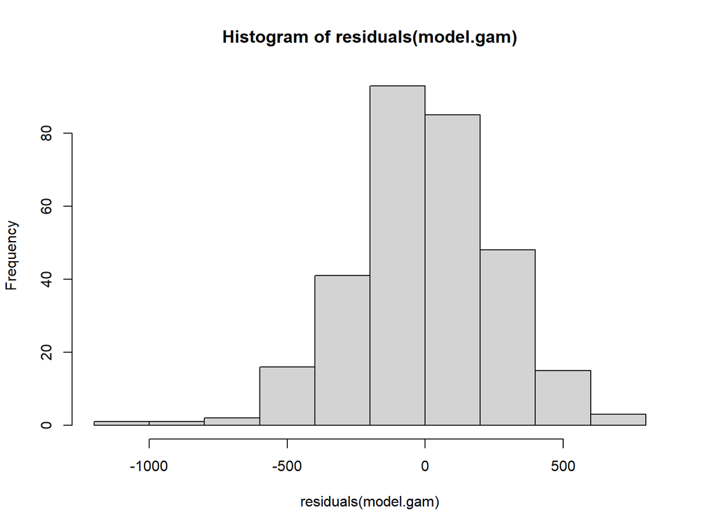

```r
hist(residuals(model.gam))
```

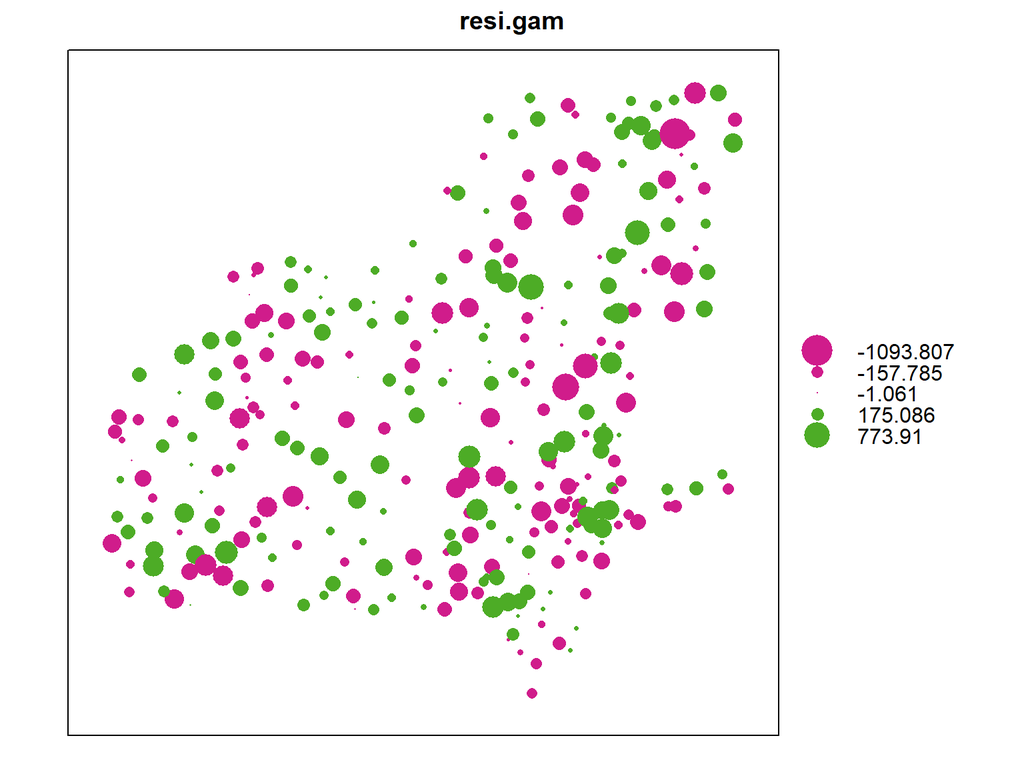

```r
ne.sp@data$resi.gam<-residuals(model.gam)
bubble(ne.sp,zcol="resi.gam")
```

Q: What is the spatial pattern of the GAM trend-surface residuals? How does this differ from the pattern of the 2nd-order trend residuals?

A: No spatial clusting?

Task: Display a map of the predictions using the `spplot` function.

```r
res.gam<-residuals(model.gam)
#Have problem with this.
#sp.grid$pred.gam<-temp$fit
#sp.grid$pred.gam.se<-temp$se.fit
#p.gam<-spplot(sp.grid,zcol="pred.gam")
```

Q: Is this trend surface a realistic representation of the growing-degree days? Explain. How does it improve on the 2nd-order trend?

A:

# 7 Thin-plate splines

Task: Load the `fields` package, to use for thin-plate spline calculation.

Task: Add a field to the stations dataframe, containing a matrix of the two coördinates, as required by the `fields` package.

Task: compute the thin-plate spline for the growing degree days, as a function of coördinates.

Task: Predict with the thin-plate spline over the study area. Note you will have to make a matrix from the grid coördinates, interpolate on that, and then convert the prediction to a field in the grid.

Task: Display the map.

Q: Is this trend surface a realistic representation of the growing-degree days? Explain. Does it improve on the GAM trend?

A:

# 8 Challenge (Optional!) – including elevation

Of course, elevation also affects temperature and thus the growing-degree days.

Repeat the exercise, but including elevation in all the models. Comment on how and why the trend surfaces (now 3D) are different/improved from the 2D trends.

In these models, consider elevation as an independent dimension, with no interaction with the geographic coördinates (although, that may not be a valid assumption… you could test this… ).

Also, see if a transformation of elevation might make its relation with the target variable more linear.

# 9 Saving the workspace

Task: Save the workspace for a later exercise using the `save.image` function: